# How Does Certain Chemical Attributes Influence Wine Quality? by Daniel Jin

# Univariate Analysis

### What is the structure of your dataset?

There are 1599 observations with 12 variables. All the variables are numeric variables.Although the ‘quality’ variable is technically an integer variable since there are no decimals associated with rating, it is left coded as a numeric variable.

### What is/are the main feature(s) of interest in your dataset?

Since I don’t know anything about red wine or the attributes about good or bad wine, it is hard to say.

I would assume that anything to do with taste would have an effect on quality. By reading the variable dictionary in the link provided, this includes: volatile acidity, citric acid, residual sugar, chlorides, total sulfur dioxide, and alcohol.

### What other features in the dataset do you think will help support your investigation into your feature(s) of interest?

I think all the variables in the dataset are of interest since I have no domain knowledge. So the remaining variables not previously mentioned will need to be investigated. This includes: fixed acidity, free sulfur dioxide, density, pH, and sulphates.

### Did you create any new variables from existing variables in the dataset?

I did not create any new variables from existing variables.

### Of the features you investigated, were there any unusual distributions? Did you perform any operations on the data to tidy, adjust, or change the form of the data? If so, why did you do this?

I did not transform any of the variables. I was able to visualize them using histograms and swarmplots. citric.acid had an unusual uniform-like distribution.

# Bivariate Plots Section

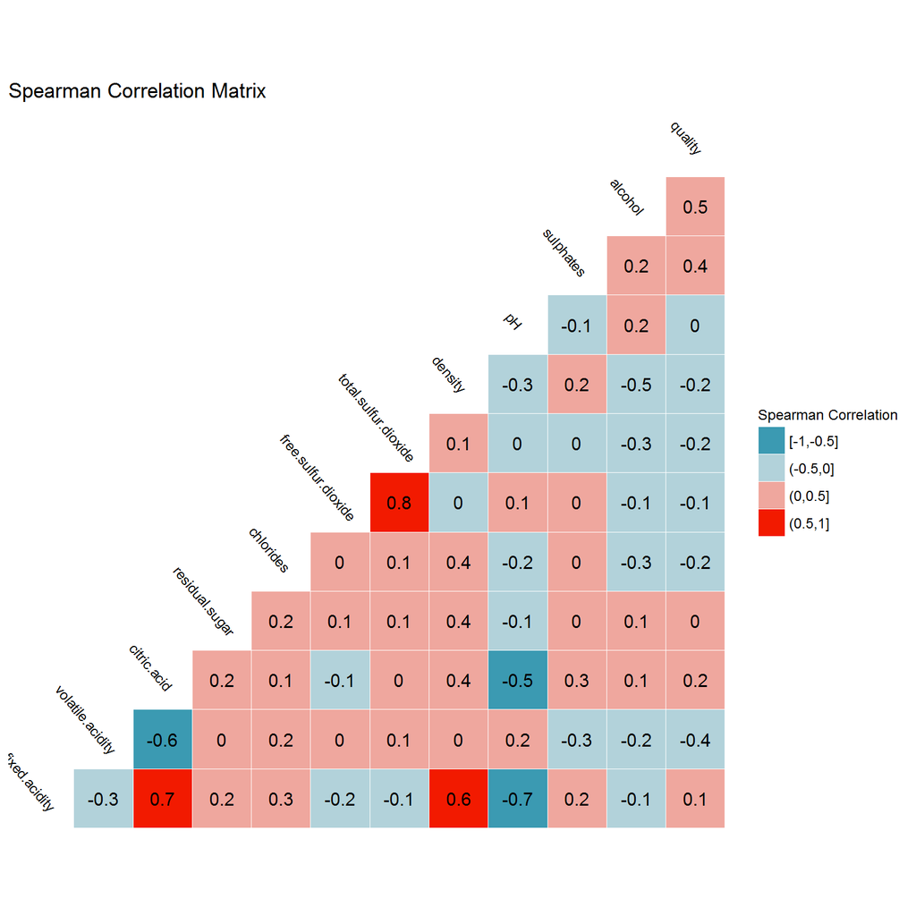

We see a negative correlation between volatile.acid with quality and a weak positive correlation between citric.acid and quality. There is a moderate correlation between alcohol and quality and sulphates and quality. Note that this means that as alcohol percent increases, quality tends to increase. The spearman correlation coefficient measures monotonic relationships instead of linear with pearson’s correlation coefficient.

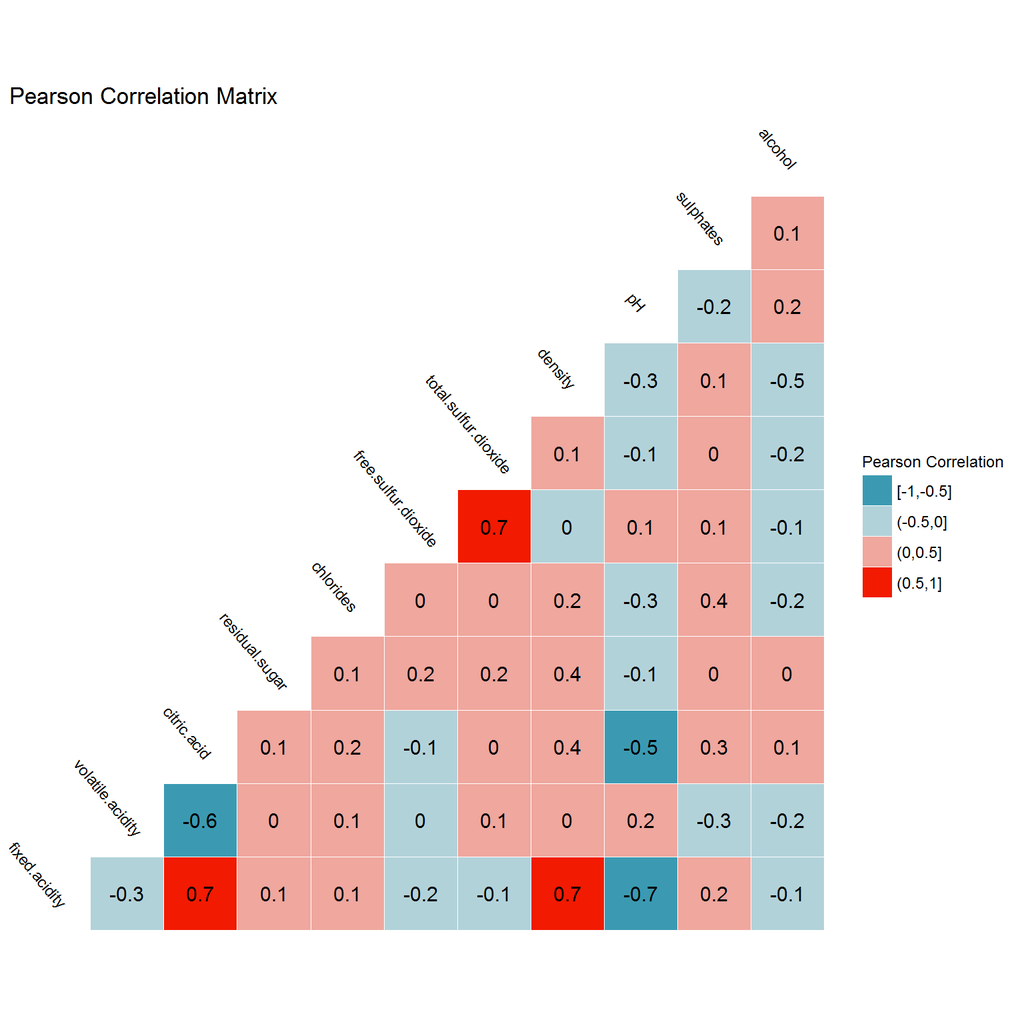

Some of the correlations we see above is as expected. There is a moderate negative correlation between citric.acid and pH. This means that as citric.acid increases, the pH goes down. This makes sense because a lower pH means that the solution is more acidic.We observe a moderate-strong negative correlation between fixed.acidity and pH. There is a strange weak positive correlation between volatile acidity and pH. This is most likely due to having a higher pH compared to fixed.acidity and citric.acid. There is a strong positive correlation between fixed.acidity and citric.acid with a weak negative correlation between fixed.acidity and volatile.acidity.

In general, these three acidic variables are a bit correlated with two of them being weakly or moderate-weakly correlated with quality. It may be more sightful to examine them further.

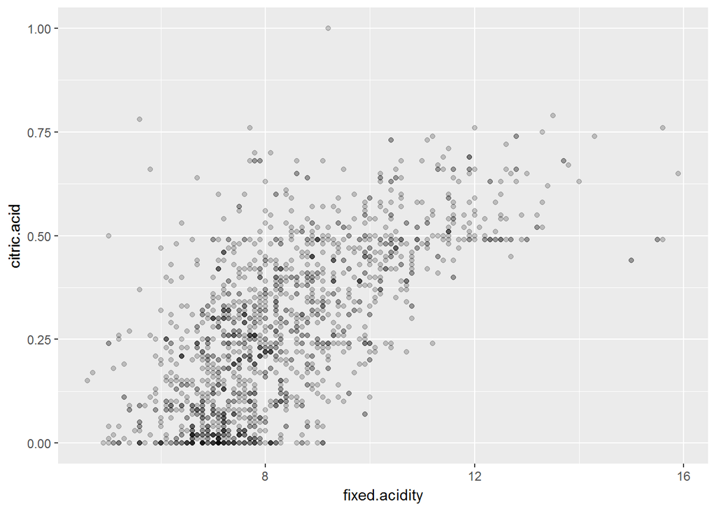

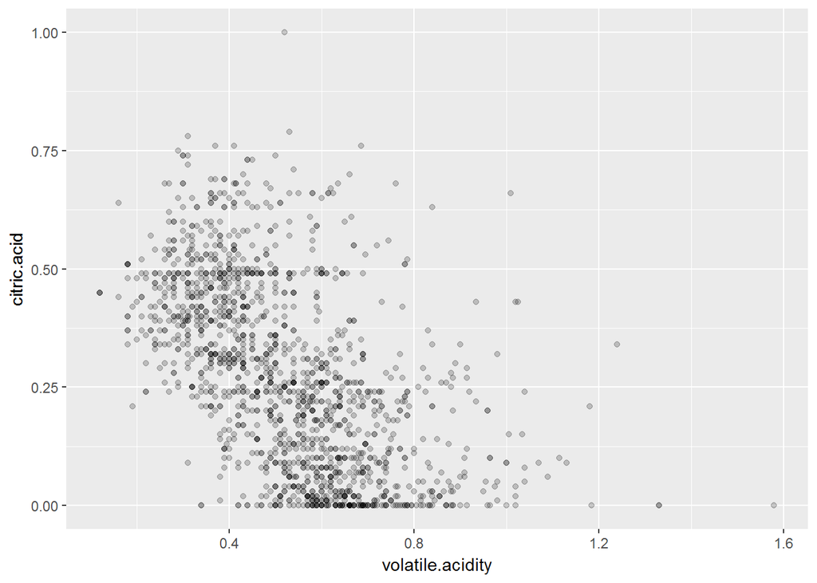

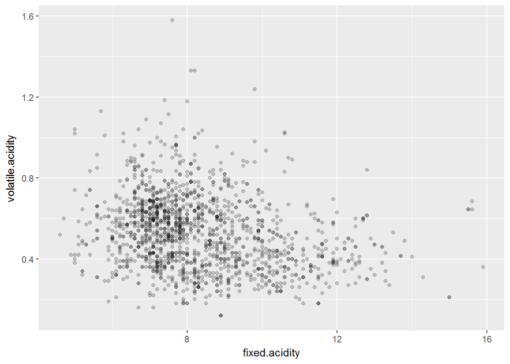

We see the relationship between these 3 acids more clearly above. When fixed.acidity increases, volatile.acidity decreases while citric.acid increases. When volatile.acidity increases, citric.acid tends to decrease. This lines up with the previous observation because it is the same thing as saying that when fixed.acidity decreases, volatile.acidity increases while citric.acid decreases because fixed.acidity decreases.

Due to a lack of domain knowledge, it is not clear if this is by coincidence or that when one decreases, the other one naturally increases.

It does make sense that when volatile.acidity increases, quality goes down because the taste of vinegar is stronger.

> Since quality is divided into 3,4,5,6,7,8 with the mode/median at 5/6, it could be useful to create a new variable for know if a wine is low quality, medium quality, or high quality based on these values. This could lead to more interesting visualizations when this new variable is an ordered factor.

```r
df$quality.type <- ifelse(df$quality > 6, 'High', ifelse(df$quality > 4,
                                                         'Medium', 'Low'))
df$quality.type <- factor(df$quality.type, levels = c('Low', 'Medium', 'High'))
```

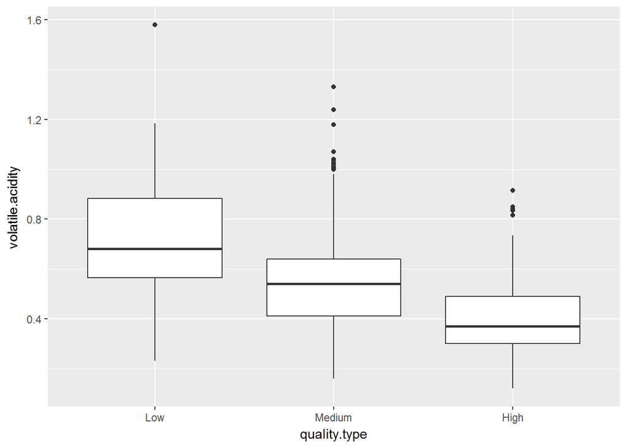

```
## df$quality.type: Low
##    Min. 1st Qu.  Median    Mean 3rd Qu.    Max.
##  0.2300  0.5650  0.6800  0.7242  0.8825  1.5800
## --------------------------------------------------------
## df$quality.type: Medium
##    Min. 1st Qu.  Median    Mean 3rd Qu.    Max.
##  0.1600  0.4100  0.5400  0.5386  0.6400  1.3300
## --------------------------------------------------------
## df$quality.type: High
##    Min. 1st Qu.  Median    Mean 3rd Qu.    Max.
##  0.1200  0.3000  0.3700  0.4055  0.4900  0.9150
```

The above plot clearly shows that higher quality wines tend to have less volatile acidity in them.

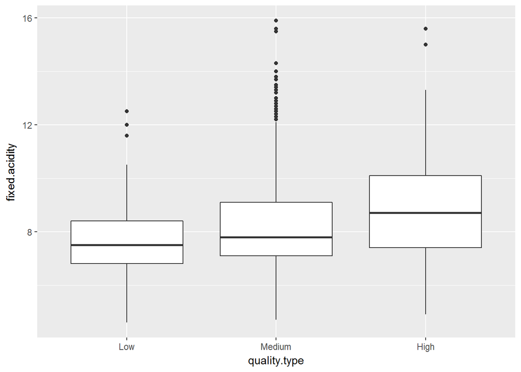

```
## df$quality.type: Low
##    Min. 1st Qu.  Median    Mean 3rd Qu.    Max.
##   4.600   6.800   7.500   7.871   8.400  12.500
## --------------------------------------------------------
## df$quality.type: Medium
##    Min. 1st Qu.  Median    Mean 3rd Qu.    Max.
##   4.700   7.100   7.800   8.254   9.100  15.900
## --------------------------------------------------------
## df$quality.type: High
##    Min. 1st Qu.  Median    Mean 3rd Qu.    Max.
##   4.900   7.400   8.700   8.847  10.100  15.600
```

On average, higher quality wines tend to have a higher fixed acidity.

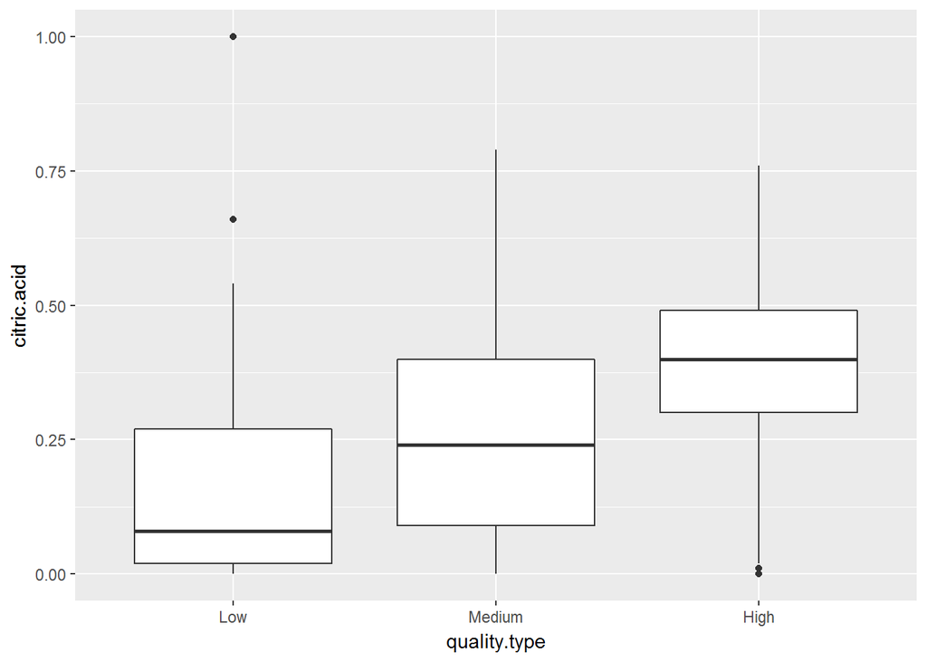

```
## df$quality.type: Low
##    Min. 1st Qu.  Median    Mean 3rd Qu.    Max.
##  0.0000  0.0200  0.0800  0.1737  0.2700  1.0000
## --------------------------------------------------------
## df$quality.type: Medium
##    Min. 1st Qu.  Median    Mean 3rd Qu.    Max.
##  0.0000  0.0900  0.2400  0.2583  0.4000  0.7900
## --------------------------------------------------------
## df$quality.type: High
##    Min. 1st Qu.  Median    Mean 3rd Qu.    Max.
##  0.0000  0.3000  0.4000  0.3765  0.4900  0.7600
```

On average, high quality wines tend to have higher citric acid content.

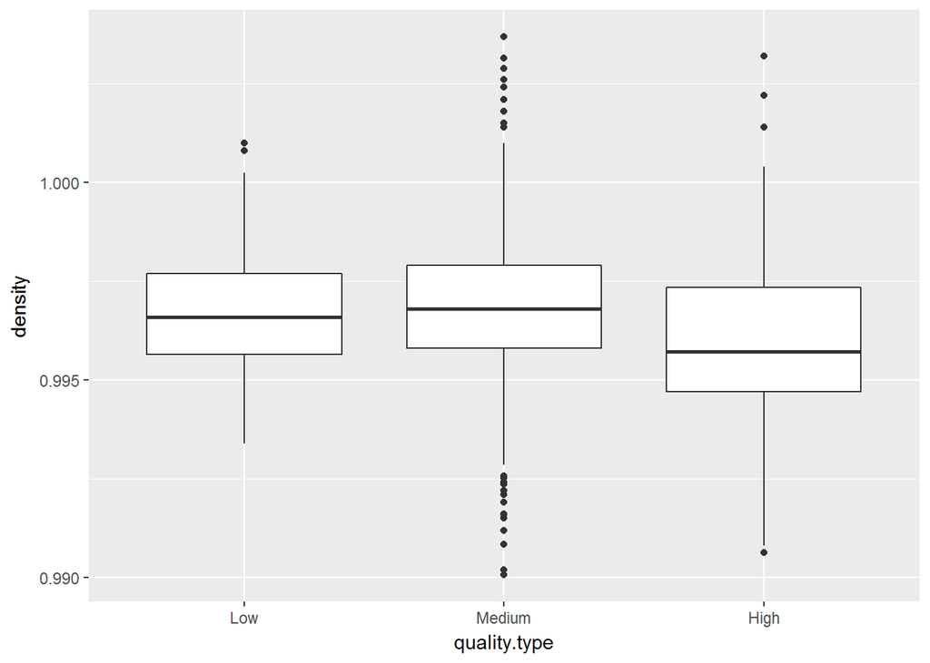

```
## df$quality.type: Low
##    Min. 1st Qu.  Median    Mean 3rd Qu.    Max.
##  0.9934  0.9957  0.9966  0.9967  0.9977  1.0010
## --------------------------------------------------------
## df$quality.type: Medium
##    Min. 1st Qu.  Median    Mean 3rd Qu.    Max.
##  0.9901  0.9958  0.9968  0.9969  0.9979  1.0037
## --------------------------------------------------------
## df$quality.type: High
##    Min. 1st Qu.  Median    Mean 3rd Qu.    Max.
##  0.9906  0.9947  0.9957  0.9960  0.9973  1.0032
```

On average, higher quality wines have lower densities. The difference is minimal.

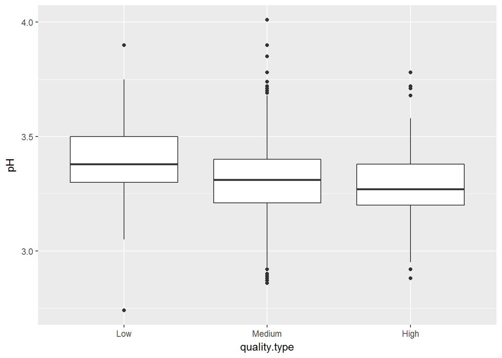

```
## df$quality.type: Low
##    Min. 1st Qu.  Median    Mean 3rd Qu.    Max.
##   2.740   3.300   3.380   3.384   3.500   3.900
## --------------------------------------------------------
## df$quality.type: Medium
##    Min. 1st Qu.  Median    Mean 3rd Qu.    Max.
##   2.860   3.210   3.310   3.311   3.400   4.010
## --------------------------------------------------------
## df$quality.type: High
##    Min. 1st Qu.  Median    Mean 3rd Qu.    Max.
##   2.880   3.200   3.270   3.289   3.380   3.780
```

On average, low quality wines tend to have a higher pH

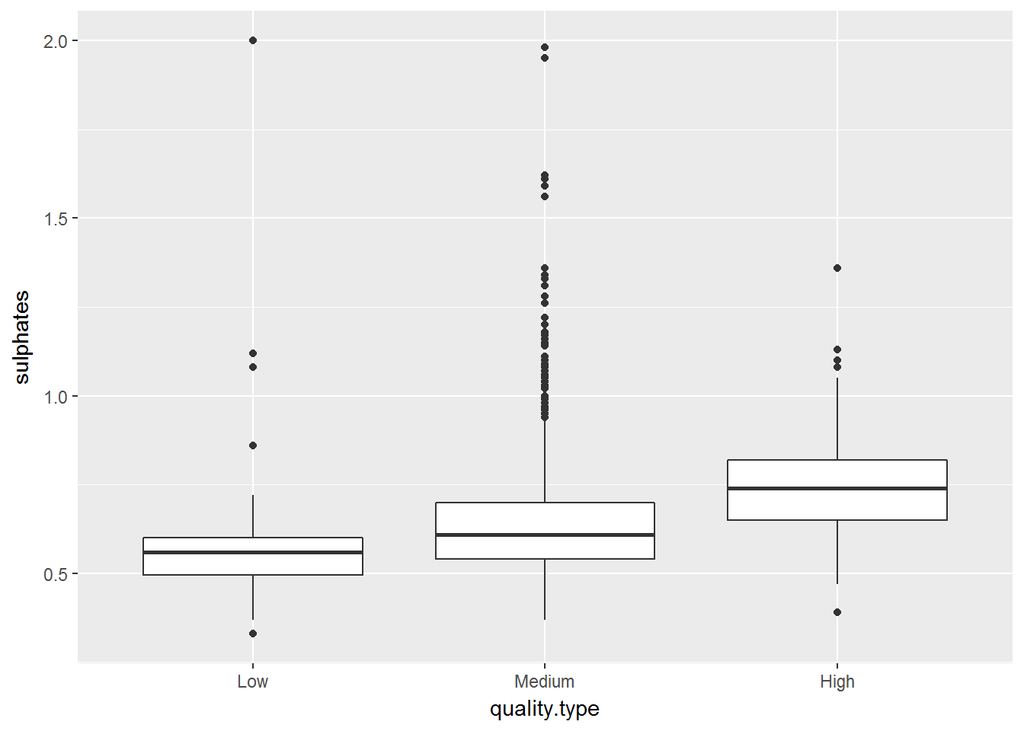

```
## df$quality.type: Low
##    Min. 1st Qu.  Median    Mean 3rd Qu.    Max.
##  0.3300  0.4950  0.5600  0.5922  0.6000  2.0000
## --------------------------------------------------------
## df$quality.type: Medium
##    Min. 1st Qu.  Median    Mean 3rd Qu.    Max.
##  0.3700  0.5400  0.6100  0.6473  0.7000  1.9800
## --------------------------------------------------------
## df$quality.type: High
##    Min. 1st Qu.  Median    Mean 3rd Qu.    Max.
##  0.3900  0.6500  0.7400  0.7435  0.8200  1.3600
```

On average, high quality wines tend to have higher sulphates

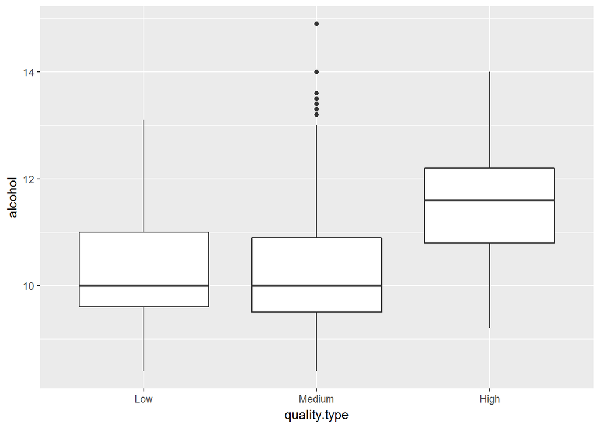

```
## df$quality.type: Low
##    Min. 1st Qu.  Median    Mean 3rd Qu.    Max.
##    8.40    9.60   10.00   10.22   11.00   13.10
## --------------------------------------------------------
## df$quality.type: Medium
##    Min. 1st Qu.  Median    Mean 3rd Qu.    Max.
##    8.40    9.50   10.00   10.25   10.90   14.90
## --------------------------------------------------------
## df$quality.type: High
##    Min. 1st Qu.  Median    Mean 3rd Qu.    Max.
##    9.20   10.80   11.60   11.52   12.20   14.00
```

On average, high quality wines tend to have higher alcohol content. There is no difference between low and medium quality wines with varying alcohol content. Most low and medium quality wines have between 9.5 to 11 percent alcohol content. While high quality wines are around 11 to 12 percent.

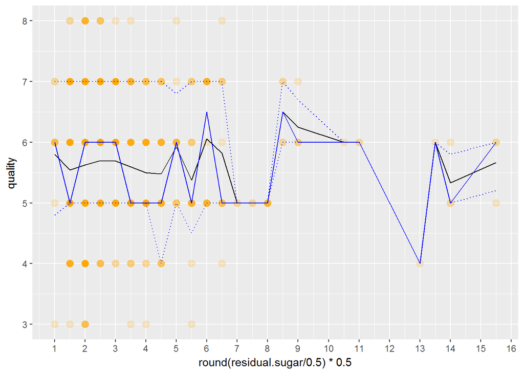

```
## df$quality.type: Low
##    Min. 1st Qu.  Median    Mean 3rd Qu.    Max.
##   1.200   1.900   2.100   2.685   2.950  12.900
## --------------------------------------------------------
## df$quality.type: Medium
##    Min. 1st Qu.  Median    Mean 3rd Qu.    Max.
##   0.900   1.900   2.200   2.504   2.600  15.500
## --------------------------------------------------------
## df$quality.type: High
##    Min. 1st Qu.  Median    Mean 3rd Qu.    Max.
##   1.200   2.000   2.300   2.709   2.700   8.900
```

Residual sugar has no correlation with quality overall, but it appears that quality peaks at around 6 and 8.5 using median as the measure. It peaks at 8.5 using mean as the measure. Given that the third quartile of residual sugar is at 2.6, the peaks observed at likely due to a lack of wines past 5 for residual sugar.

High quality wines have the highest median and mean residual sugar.

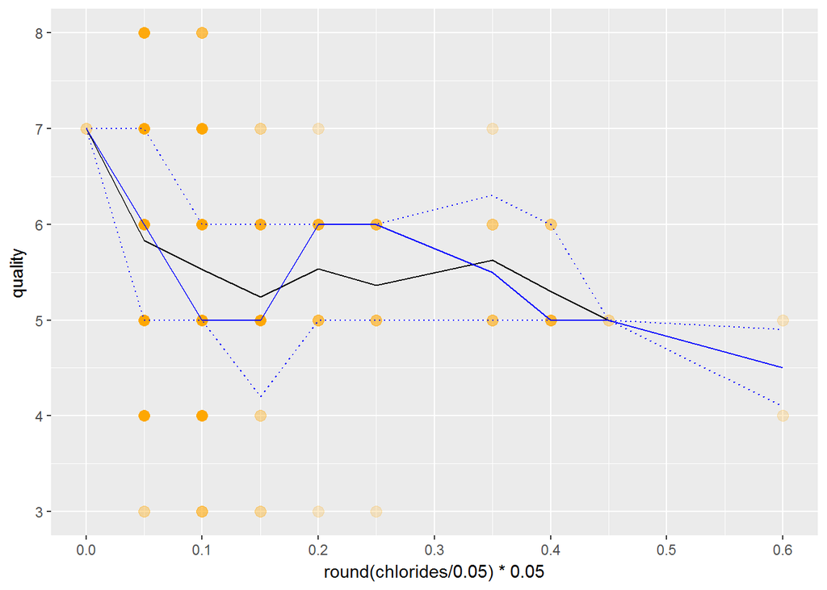

```
## df$quality.type: Low
##    Min. 1st Qu.  Median    Mean 3rd Qu.    Max.
## 0.04500 0.06850 0.08000 0.09573 0.09450 0.61000
## --------------------------------------------------------
## df$quality.type: Medium
##    Min. 1st Qu.  Median    Mean 3rd Qu.    Max.
## 0.03400 0.07100 0.08000 0.08897 0.09100 0.61100
## --------------------------------------------------------
## df$quality.type: High
##    Min. 1st Qu.  Median    Mean 3rd Qu.    Max.
## 0.01200 0.06200 0.07300 0.07591 0.08500 0.35800
```

Wine quality is highest when chlorides are minimized. Wine quality decreases when chlorides increases toward the 0.10 value. But quality increases when chlorides are between 0.2 and 0.25 and are equivalent to when chlorides are about 0.05. After the chloride content in a wine increases past 0.25, the quality only decreases. On average, wine quality decreases when there are more chlorides in the wine.

High quality wines have the lowest median and average chloride content.

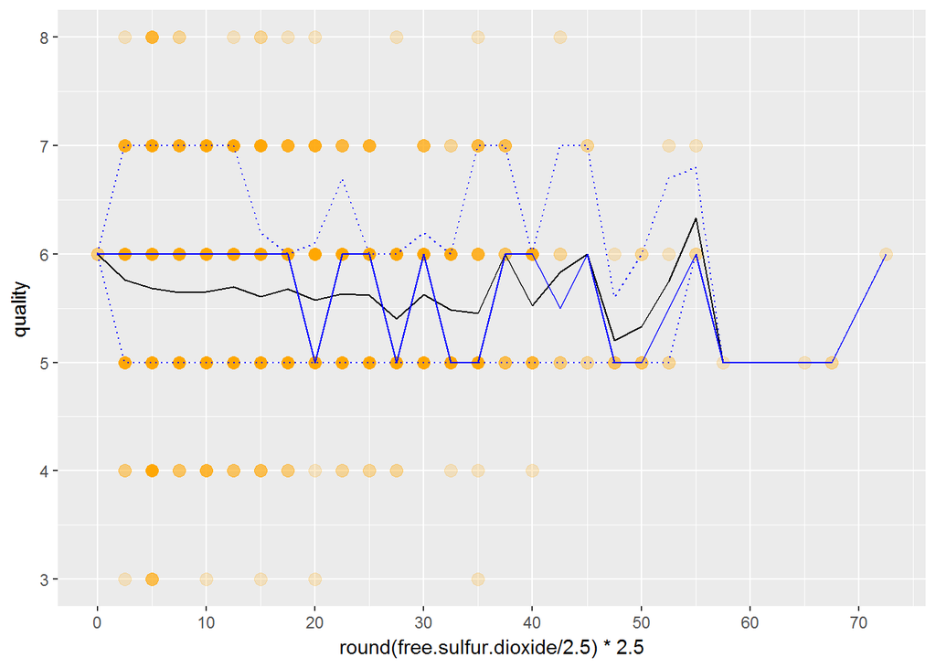

```
## df$quality.type: Low
##    Min. 1st Qu.  Median    Mean 3rd Qu.    Max.
##    3.00    5.00    9.00   12.06   15.50   41.00
## --------------------------------------------------------
## df$quality.type: Medium
##    Min. 1st Qu.  Median    Mean 3rd Qu.    Max.
##    1.00    8.00   14.00   16.37   22.00   72.00
## --------------------------------------------------------
## df$quality.type: High
##    Min. 1st Qu.  Median    Mean 3rd Qu.    Max.
##    3.00    6.00   11.00   13.98   18.00   54.00
```

There doesn’t seem to be any significant relationship or trends of free sulfur dioxide content in the wine with quality. However, on average wines with free sulfur dioxide content of 55 tend to have a tiny bit higher quality on average compared to other values of free sulfur dioxide.

Low quality wines have the lowest amount of median and mean free sulfur dioxide.

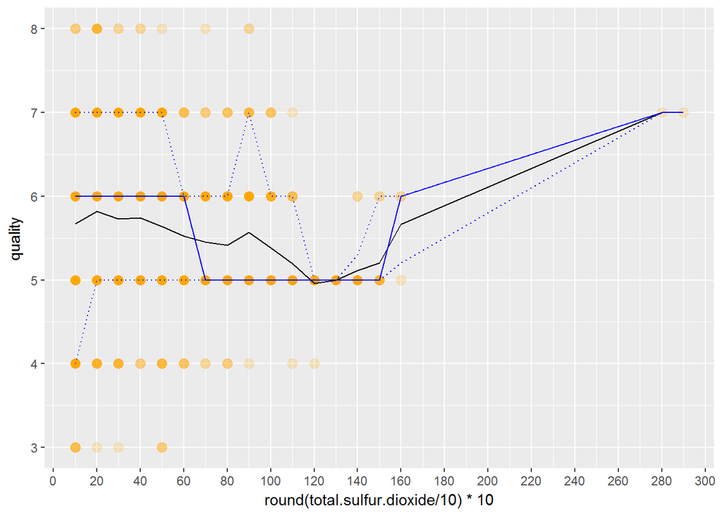

```
## df$quality.type: Low
##    Min. 1st Qu.  Median    Mean 3rd Qu.    Max.
##    7.00   13.50   26.00   34.44   48.00  119.00
## --------------------------------------------------------
## df$quality.type: Medium
##    Min. 1st Qu.  Median    Mean 3rd Qu.    Max.
##    6.00   24.00   40.00   48.95   65.00  165.00
## --------------------------------------------------------
## df$quality.type: High
##    Min. 1st Qu.  Median    Mean 3rd Qu.    Max.
##    7.00   17.00   27.00   34.89   43.00  289.00
```

Wine quality increases drastically when total sulfur dioxide content is at 280-290, though this could just be outliers. Wine quality at 160 total sulfur dioxide is about the same as when there is around 10-40 total sulfur dioxide in the wine. The wines with between 40-160 total sulfur dioxide have the lowest quality with the lowest at 120. Using median as the measure, wines appear to have higher quality when total sulfur dioxide is around 60 or below.

Looking at the summary it looks like when there’s too little total sulfur dioxide it’s associated with low quality wines.

> Since there could be a relationship between free sulfur dioxide and total sulfur dioxide, I’ll make a ratio between them to see if there’s an ideal ratio

```r
df$free.total.sulfur <- df$free.sulfur.dioxide/df$total.sulfur.dioxide
```

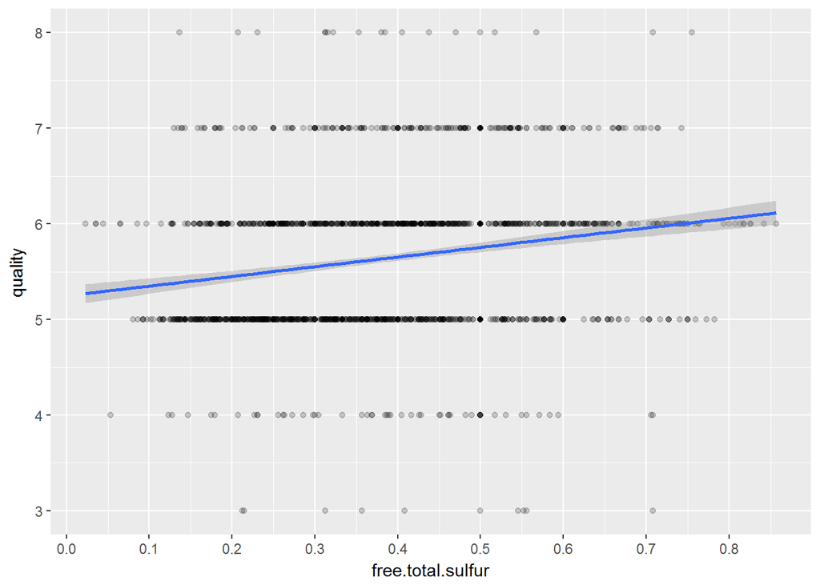

It appears that as the ratio between free total sulfur dioxide to total sulfur dioxide increases, the quality increases. The best ratio observed is around 0.85.

# Bivariate Analysis

### Talk about some of the relationships you observed

Higher fixed acidity is associated with higher citric acid content, higher volatile acid content is associated with lower citric acid content, and higher fixed acidity content is associated with lower volatile acid content.

The quality in a wine peaks when the residual sugar is around 6 or between 8.5 and 10.5. Higher quality wines have less chlorides in general. Wines with a free sulfur dioxide content of around 55 have slightly higher qualities. The highest quality wines have a total sulfur dioxide content of 280-290 using median as the measure, though this is likely due to outliers. In general, a total sulfur dioxide of around 60 and below are ideal. As the ratio between free sulfur dioxide to total sulfur dioxide increases, the quality of wine increases, with the best observed ratio at around 0.85.

With the summaries, we saw that higher quality wines have more residual sugar, low quality wines have the least amount of free sulfur dioxide and total sulfur dioxide.

### What was the strongest relationship you found?

Alcohol had the highest correlation for quality with a value of 0.5. The box plot showing alcohol and quality was the only box plot with the first quartile of the high quality group being around the same value of the 3rd quartile of the other two groups. This clearly shows that higher quality wines tend to have alcohol contents between 11 and 12 percent while low and medium quality wines are between 9.5 and 11.

There is also a strong relationship between low volatile acidity and high quality wine.

# Multivariate Plots Section

Earlier we saw that quality increases as the ratio of free sulfur dioxide to total sulfur dioxide increases. We can see if the total sulfur dioxide in the wine also plays a role in quality or does only the ratio matter.

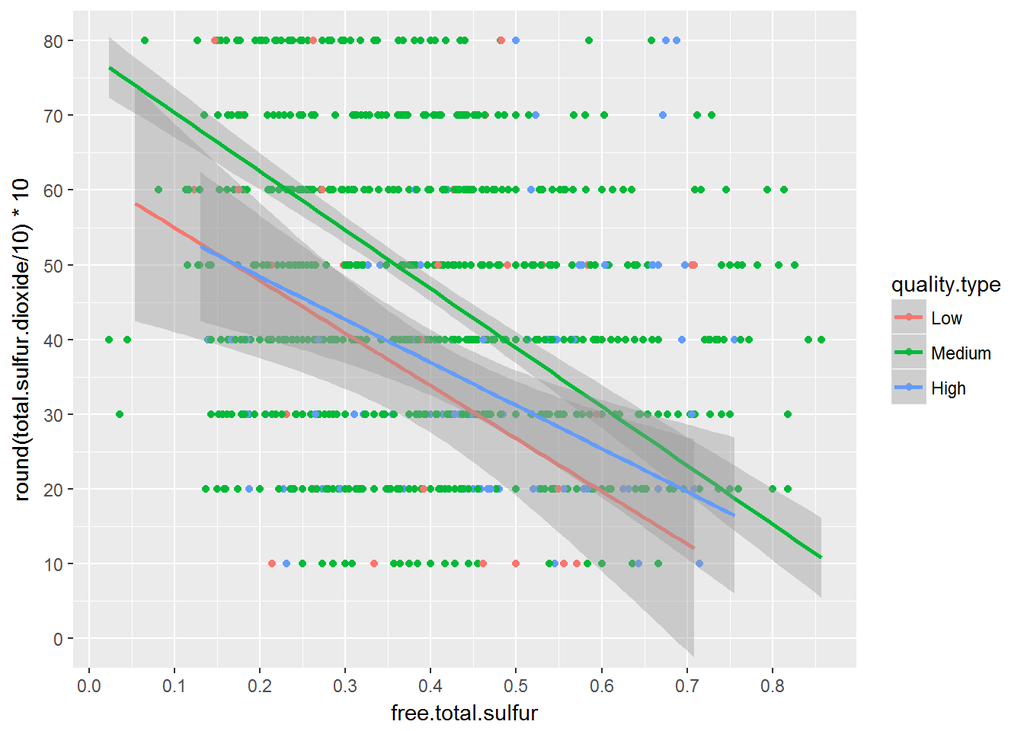

From the plot above it’s interesting to see that there are two almost parallel lines between the low quality and medium quality wine. The high quality line is nearly between the two lines, but does overlap with the low quality wines a little.

In bivariate analysis, we thought that having a higher ratio between free sulfur dioxide to total sulfur dioxide was better, but this is not the case.

In general, it seems that having a total sulfur dioxide of around 15 to 50 and free to total sulfur dioxide ratio between 0.15 to 0.75 results in highest quality wine. One thing to keep in mind is that these two depend on each other. In general, as the ratio between free and total sulfur dioxide increases, the total sulfur dioxide should decrease.

We found previously that higher quality wines is associated with higher residual sugar and more alcohol content. I know from common knowledge that low alcohol percent are the ones that tend to have high residual sugar. We can adjust for the effects of alcohol content and see if high quality wines still have more residual sugar. Since we also know that volatile acidity and chlorides decrease the quality of alcohol, we can see what happens to residual sugar when we adjust for those effects as well.

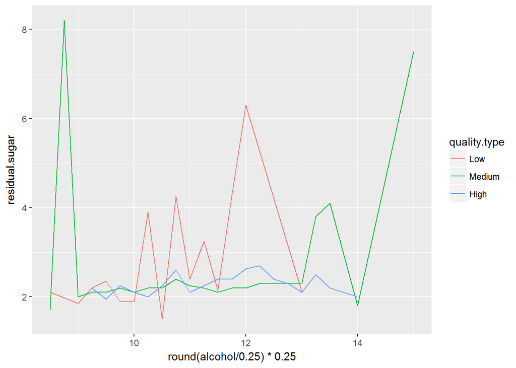

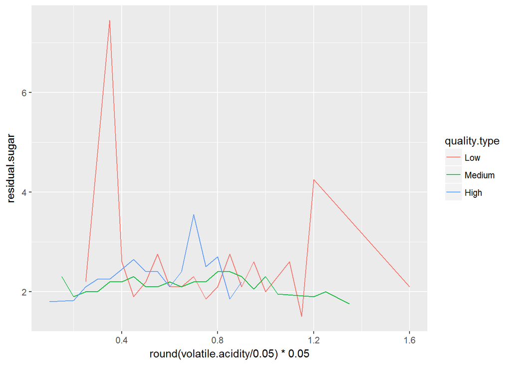

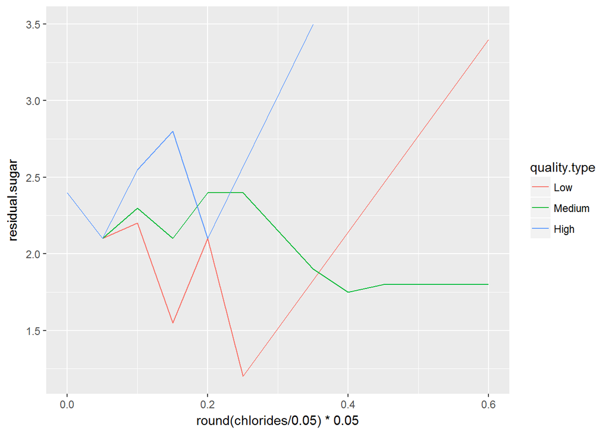

After adjusting for volatile acidity, there is no clear relationship. It looks like high quality wines have more residual sugar than medium quality wines, but is split 50-50 between low quality wines.

After adjusting for chloride content in a wine, high quality wines tend to have more residual sugar compared to lower quality wines.

There was also a lot of correlation between fixed acidity, volatile acidity, and citric acid. We can examine what happens to the quality of wine when we adjust for each one the three acids and compare it to the other two acids.

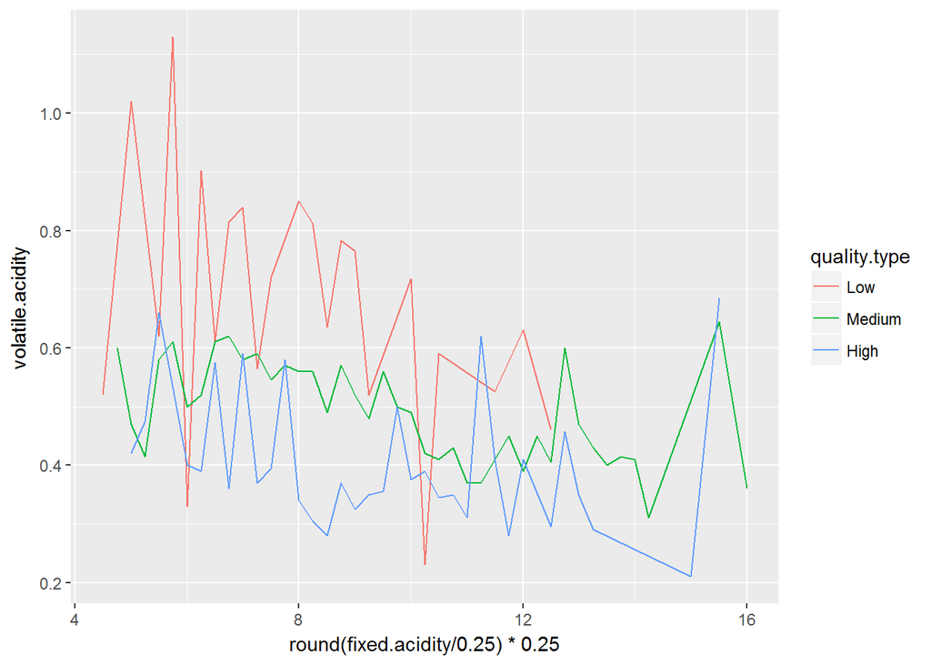

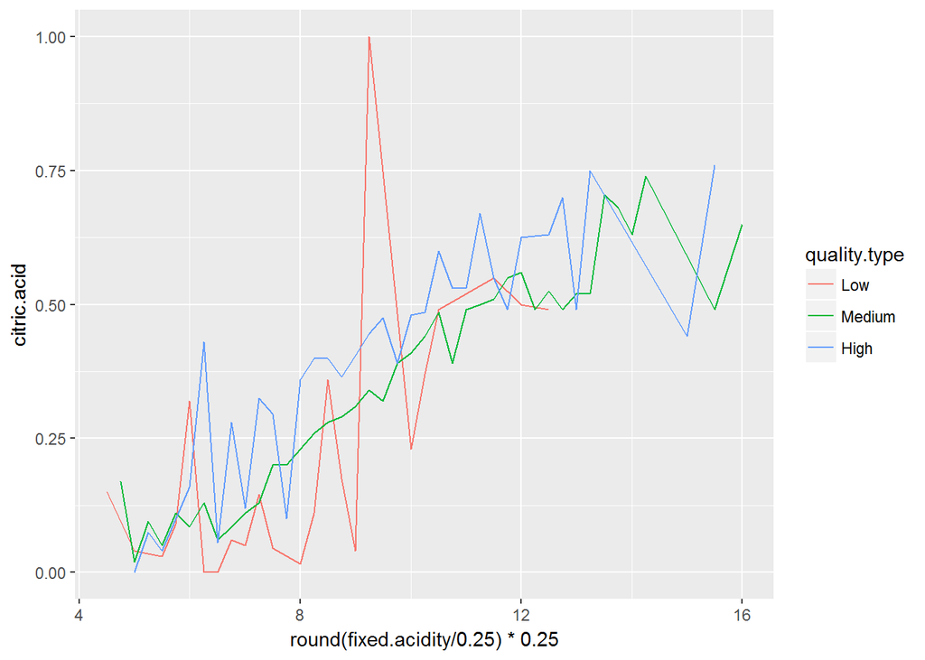

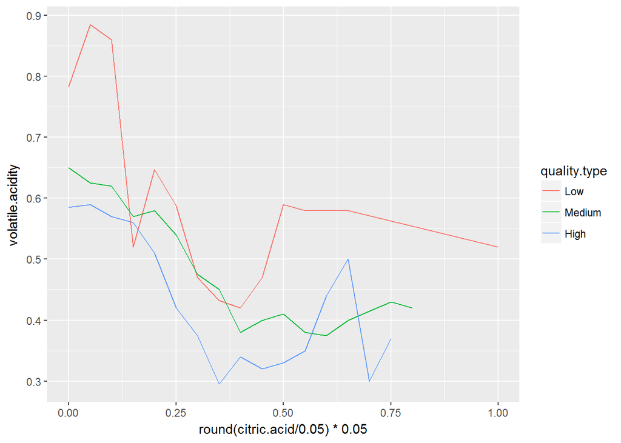

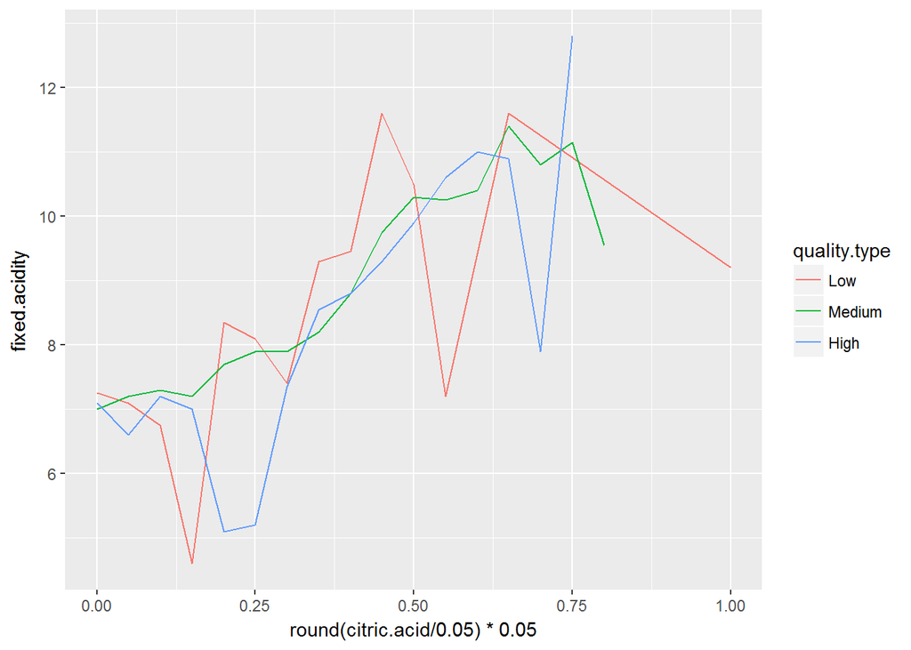

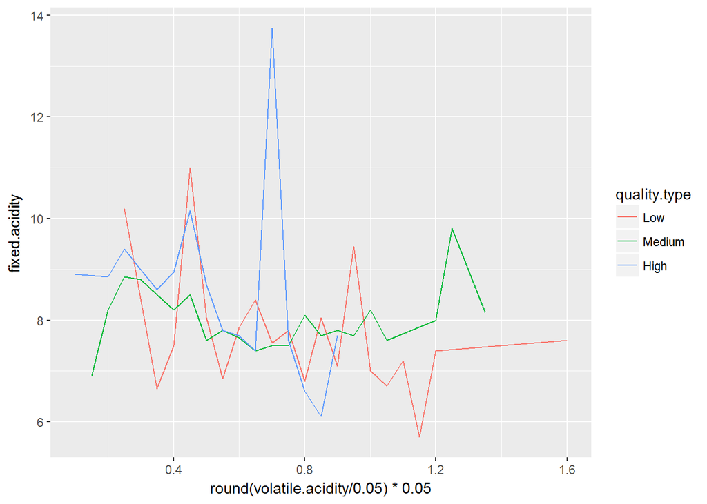

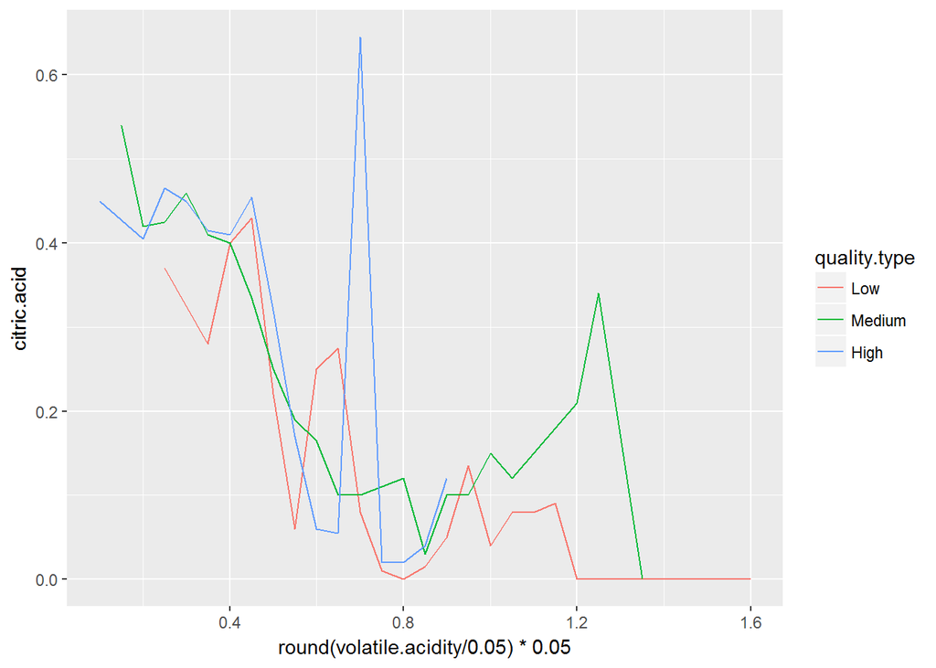

Adjusting for fixed acidity, higher quality wines tend to have lower volatile acidity content and higher amount of citric compared to medium and low quality wines. Very high citric acid or volatile acidity is only associated with low quality wines.

Adjusting for citric acid, higher quality wines tend to have lower volatile acidity content compared to medium and low quality wines. Low quality wines have the highest volatile acidity content.There is no clear relationship of fixed acidity after adjusting for citric acid between the wine qualities. Low qualities wines just tend to have higher fixed acidity than medium and high quality wines.

Adjusting for volatile acidity, there is no clear relationship. It looks like high quality wines have higher fixed acidity and citric acid content compared to medium and low quality wines. This makes sense because higher fixed acidity and citric acid content is associated with higher quality wines.